# Soc723 - MD Chapter 5

Turgut Keskintürk

2023-01-16

Hello there! Let’s start with our exercises for Chapter 5.

I am assuming that we are OK **not using** Bayesian stuff for this homework, so I am equipped with the sweet smells of `lm`.

Let’s load the data and clean it up a bit.

```r
d <- read.csv(
  "https://raw.githubusercontent.com/vaiseys/223_course/main/Data/twitchdata-update.csv"
) |> clean_names()
```

# Question 1

We are first going to look at the raw data of five random streamers:

```r
set.seed(112358)
sample_n(d, 5) |>
  select(followers, average_viewers) |>
  kable(digits = 2, align = "c")
```

| followers | average_viewers |
| --- | --- |
| 656860 | 2795 |
| 68907 | 1796 |
| 220819 | 1237 |
| 542580 | 5368 |
| 157981 | 1444 |

Well, it seems that there is a relation, but no, I hate reading raw data, so let me continue by summarizing and visualizing it.

```r
d |>
  select(followers, average_viewers) |>
  summary()
```

```
##    followers       average_viewers
##  Min.   :   3660   Min.   :   235
##  1st Qu.: 170546   1st Qu.:  1458
##  Median : 318063   Median :  2425
##  Mean   : 570054   Mean   :  4781
##  3rd Qu.: 624332   3rd Qu.:  4786
##  Max.   :8938903   Max.   :147643
```

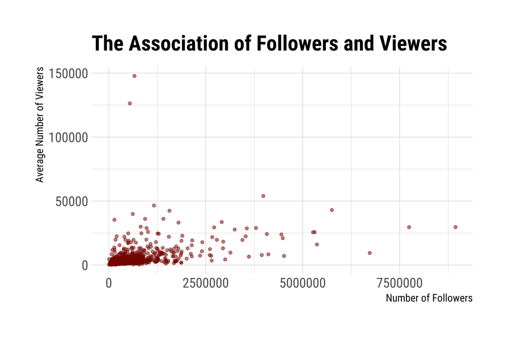

```r
d |>
  ggplot(aes(followers, average_viewers)) +
  geom_point(alpha = 0.5, size = 1, color = "#720500") +
  labs(
    title = "The Association of Followers and Viewers",
    x = "Number of Followers",
    y = "Average Number of Viewers")
```

As Nico says, the data is packed into a small part of the plane. Let’s redraw it:

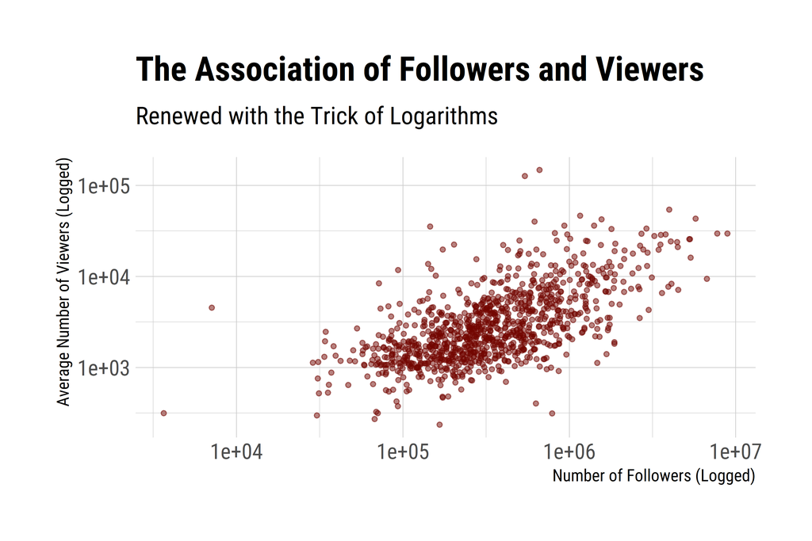

```r
d |>
  ggplot(aes(followers, average_viewers)) +
  geom_point(alpha = 0.5, size = 1, color = "#720500") +
  labs(
    title = "The Association of Followers and Viewers",
    subtitle = "Renewed with the Trick of Logarithms",
    x = "Number of Followers (Logged)",
    y = "Average Number of Viewers (Logged)") +
  scale_x_log10() +
  scale_y_log10()
```

Aha, it seems that there is a clear relationship between the number of viewers and the number of followers. That’s useful:

```r
d <- d |> mutate(
  l_viewers = log10(average_viewers),
  l_follows = log10(followers)
)
```

# Question 2

A fit:

```r
fit <- lm(l_viewers ~ l_follows, data = d)
broom::tidy(fit) |>
  select(-p.value) |>
  mutate(term = ifelse(term == "l_follows", "Followers", term)) |>
  kable(digits = 2, align = "c") # don't show the p-values!
```

| term | estimate | std.error | statistic |
| --- | --- | --- | --- |
| (Intercept) | 0.20 | 0.13 | 1.58 |
| Followers | 0.59 | 0.02 | 26.04 |

Alright, our coefficient is 0.59, so $1.1^{0.59} = 1.058$ means that 10% increase in followers results in 5.8% increase in average viewers.

# Question 3

OK, I am going to plot the residuals of this model:

```r
d.pred <- augment(fit)
glimpse(d.pred)
```

```
## Rows: 1,000
## Columns: 8
## $ l_viewers  <dbl> 4.442731, 4.408410, 4.040444, 3.887280, 4.471321, 4.627509,…
## $ l_follows  <dbl> 6.511388, 6.725108, 6.247393, 6.596030, 6.951284, 6.194081,…
## $ .fitted    <dbl> 4.029761, 4.155534, 3.874400, 4.079572, 4.288638, 3.843027,…
## $ .resid     <dbl> 0.4129697, 0.2528757, 0.1660436, -0.1922928, 0.1826833, 0.7…
## $ .hat       <dbl> 0.006194481, 0.008694557, 0.003782169, 0.007126066, 0.01187…
## $ .sigma     <dbl> 0.3085580, 0.3087321, 0.3087919, 0.3087764, 0.3087820, 0.30…
## $ .cooksd    <dbl> 0.0056128779, 0.0029688873, 0.0005513456, 0.0014026033, 0.0…
## $ .std.resid <dbl> 1.3420109, 0.8227954, 0.5389316, -0.6251793, 0.5953620, 2.5…
```

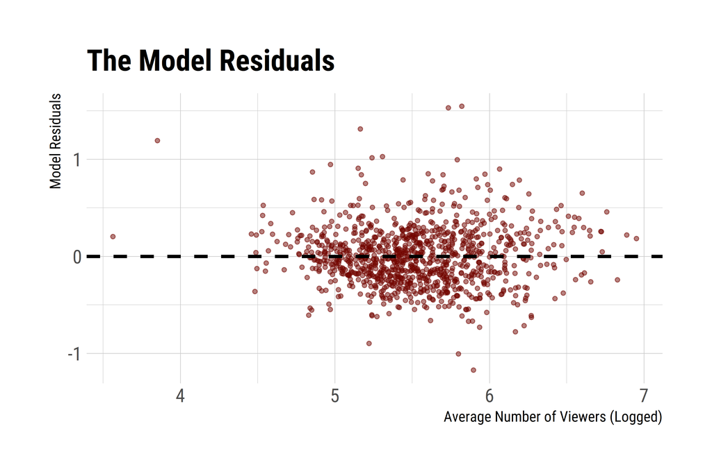

```r
d.pred |>
  ggplot(aes(x = l_follows, .resid)) +
  geom_point(alpha = 0.5, size = 1, color = "#720500") +
  labs(
    title = "The Model Residuals",
    x = "Average Number of Viewers (Logged)",
    y = "Model Residuals") +
  geom_hline(aes(yintercept = 0), linetype = "dashed", col = "black", linewidth = 1)
```

Not bad to be honest, but there many bits out of their league. Particularly where the logged values are between 5 and 6.

# Question 4

Some descriptions of the data at hand. Nico was talking about using `average_viewers`, but I guess the logged version is better.

```r
# tabulate
d |>
  count(language)
```

```
##      language   n
## 1      Arabic   5
## 2     Chinese  30
## 3       Czech   6
## 4     English 485
## 5     Finnish   1
## 6      French  66
## 7      German  49
## 8       Greek   1
## 9   Hungarian   2
## 10    Italian  17
## 11   Japanese  10
## 12     Korean  77
## 13      Other   1
## 14     Polish  12
## 15 Portuguese  61
## 16    Russian  74
## 17     Slovak   1
## 18    Spanish  68
## 19    Swedish   1
## 20       Thai  11
## 21    Turkish  22
```

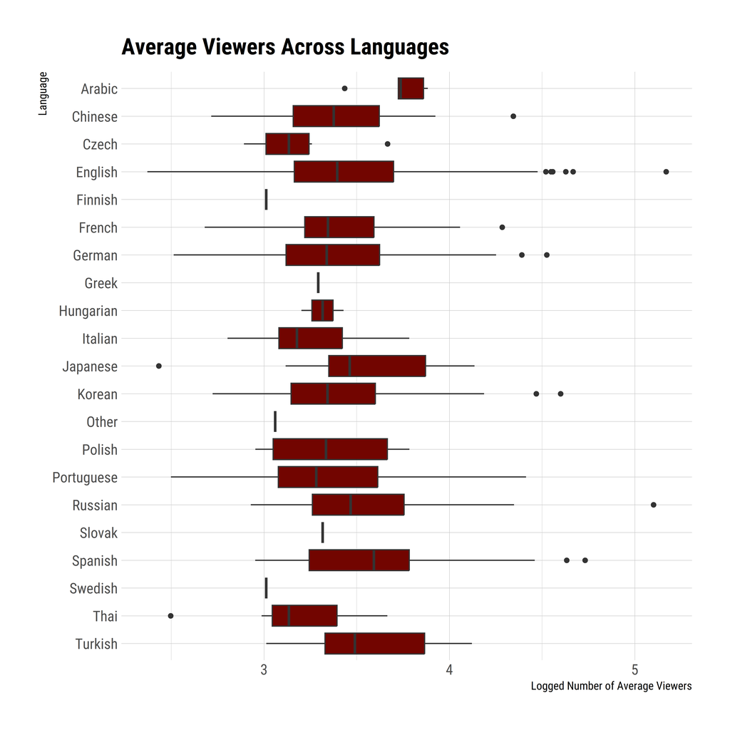

```r
# plot the relationship
d |>
  ggplot(aes(x = reorder(language, desc(language)), y = l_viewers)) +
  geom_boxplot(fill = "#720500") +
  labs(title = "Average Viewers Across Languages",
       x = "Language", y = "Logged Number of Average Viewers") +
  coord_flip()
```

# Question 5

Another regression. Let’s see what’s gonna come out of it:

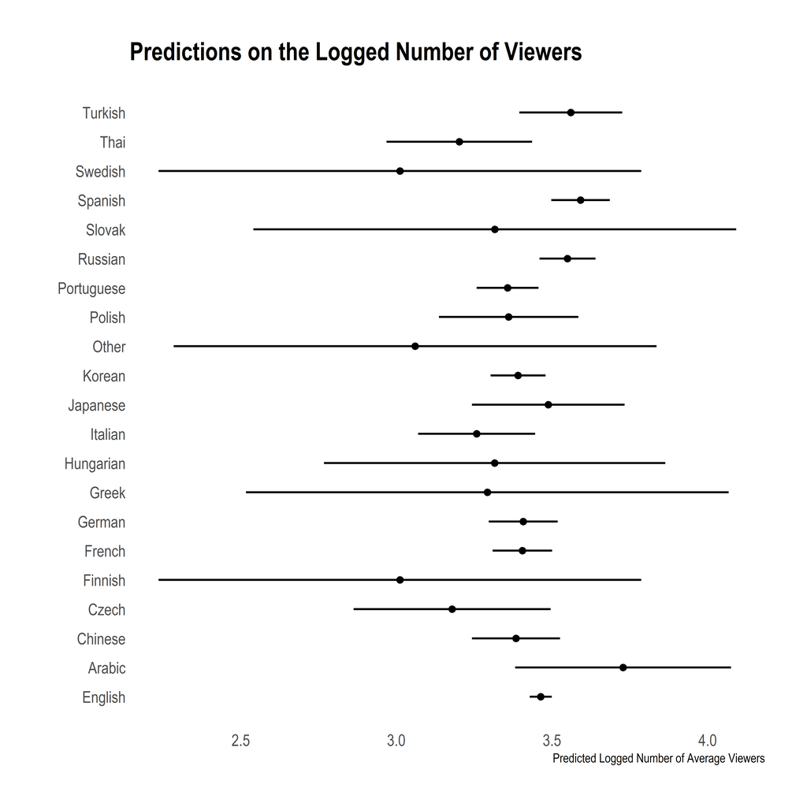

```r
d <- d |>
  mutate(language = as.factor(language),
         language = relevel(language, ref = "English"))

fit <- lm(l_viewers ~ language, data = d)

ggeffects::ggpredict(fit, terms = "language") |>
  plot() + coord_flip() +
  labs(title = "Predictions on the Logged Number of Viewers",
       x = "", y = "Predicted Logged Number of Average Viewers") +
  theme_ipsum(grid = "none")
```

Nico’s prediction is not bad, but there are wild fluctuations! Mainly because of the size in those categories.

# Question 6

Let’s explore the residuals.

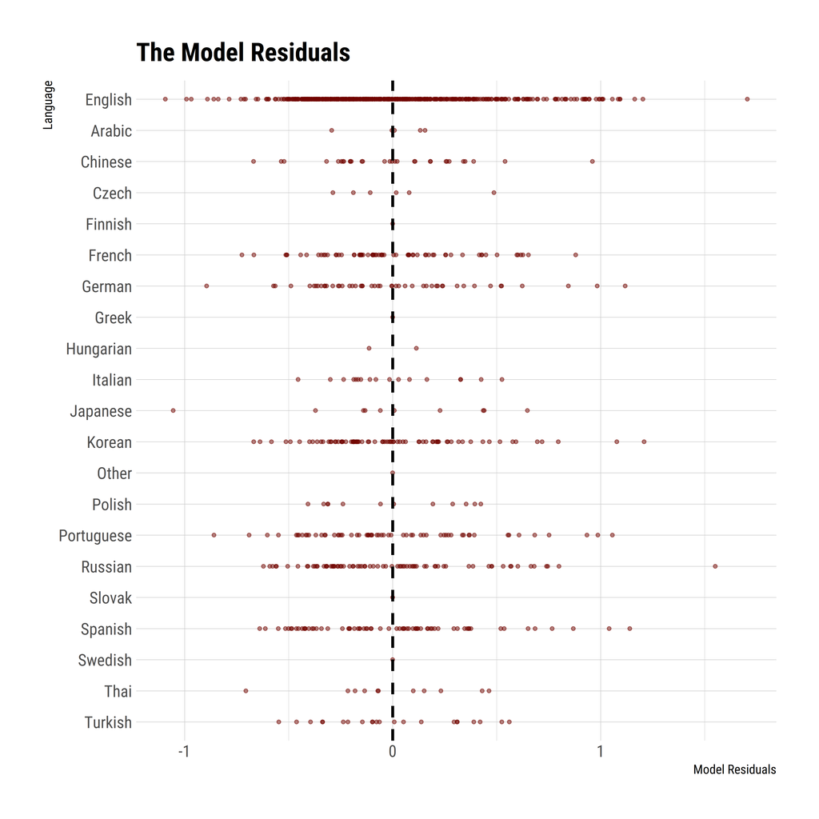

```r
augment(fit) |>
  ggplot(aes(x = reorder(language, desc(language)), .resid)) +
  geom_point(alpha = 0.5, size = 1, color = "#720500") +
  labs(
    title = "The Model Residuals",
    x = "Language",
    y = "Model Residuals") +
  geom_hline(aes(yintercept = 0), linetype = "dashed", col = "black", linewidth = 1) +
  coord_flip()
```

Huh, too much variation in some languages. Look at the far right side of the English streamers and the Russian ones, and the left side of the Japanese. We gotta get into the world of streamers, but no, *I prefer not to.*

Thank you!